# Detecting Fraud Transactions by numerous Machine Learning technics

## About this notebook:

The whole point of this notebook is to try catch up autoencoder representation of fraud transaction and compared the result of models which was learned on this prepared data by this algorithm with models fed by original data. We expect dimensionality reduction with the same or with the better results. The notebook consist:

- Data analysis
- Undersampling
- PCA and TSNE
- Autoencoder as data preporation for standard supervised algorithm: Logistic Regression, Random Forrest, SVM and XGBoost

Since this is a complex dataset, the following analyzes will be performed in the future::

- Outlier detection
- Oversampling

**We will measure the performance mainly by AUROC and AUPRC**

## Data Information:

*https://www.kaggle.com/datasets/mlg-ulb/creditcardfraud*

The dataset contains transactions made by credit cards in September 2013 by European cardholders. This dataset presents transactions that occurred in two days, where we have 492 frauds out of 284,807 transactions. The dataset is highly unbalanced, the positive class (frauds) account for 0.172% of all transactions.

It contains only numerical input variables which are the result of a PCA transformation. Unfortunately, due to confidentiality issues, we cannot provide the original features and more background information about the data. Features V1, V2, … V28 are the principal components obtained with PCA, the only features which have not been transformed with PCA are 'Time' and 'Amount'. Feature 'Time' contains the seconds elapsed between each transaction and the first transaction in the dataset. The feature 'Amount' is the transaction Amount, this feature can be used for example-dependant cost-sensitive learning. Feature 'Class' is the response variable and it takes value 1 in case of fraud and 0 otherwise.

## Libraries

```python
import pandas as pd
from sklearn.compose import make_column_selector as selector
import numpy as np
import random
import os
import seaborn as sns
import matplotlib.pyplot as plt

from sklearn.model_selection import train_test_split
from sklearn.model_selection import cross_val_score
from sklearn.metrics import classification_report
from sklearn.metrics import RocCurveDisplay, PrecisionRecallDisplay
from sklearn.metrics import confusion_matrix
from sklearn.experimental import enable_halving_search_cv
from sklearn.model_selection import HalvingGridSearchCV

from sklearn.svm import SVC
from sklearn.linear_model import LogisticRegression
from sklearn.ensemble import GradientBoostingClassifier
from sklearn.ensemble import RandomForestClassifier

from sklearn.decomposition import PCA
from sklearn.preprocessing import StandardScaler
from sklearn.manifold import TSNE

from keras.layers import Input, Dense
from keras.models import Model, Sequential
from keras import regularizers
from keras.callbacks import EarlyStopping
import keras

from numpy.random import seed
import tensorflow as tf
```

```python
import warnings
warnings.filterwarnings('ignore')
```

```python
seed_value= 22

# 1. Set the `PYTHONHASHSEED` environment variable at a fixed value
os.environ['PYTHONHASHSEED']='0'

# 2. Set the `python` built-in pseudo-random generator at a fixed value
random.seed(seed_value)

# 3. Set the `numpy` pseudo-random generator at a fixed value
np.random.seed(seed_value)

# 4. Set the `tensorflow` pseudo-random generator at a fixed value
tf.random.set_seed(seed_value)
keras.utils.set_random_seed(seed_value)
```

```python
df = pd.read_csv("creditcard.csv")
```

# Data Analysis

We will look into data:

```python
df.head()
```

|  | Time | V1 | V2 | V3 | V4 | V5 | V6 | V7 | V8 | V9 | ... | V21 | V22 | V23 | V24 | V25 | V26 | V27 | V28 | Amount | Class |
| --- | --- | --- | --- | --- | --- | --- | --- | --- | --- | --- | --- | --- | --- | --- | --- | --- | --- | --- | --- | --- | --- |
| 0 | 0.0 | -1.359807 | -0.072781 | 2.536347 | 1.378155 | -0.338321 | 0.462388 | 0.239599 | 0.098698 | 0.363787 | ... | -0.018307 | 0.277838 | -0.110474 | 0.066928 | 0.128539 | -0.189115 | 0.133558 | -0.021053 | 149.62 | 0 |
| 1 | 0.0 | 1.191857 | 0.266151 | 0.166480 | 0.448154 | 0.060018 | -0.082361 | -0.078803 | 0.085102 | -0.255425 | ... | -0.225775 | -0.638672 | 0.101288 | -0.339846 | 0.167170 | 0.125895 | -0.008983 | 0.014724 | 2.69 | 0 |
| 2 | 1.0 | -1.358354 | -1.340163 | 1.773209 | 0.379780 | -0.503198 | 1.800499 | 0.791461 | 0.247676 | -1.514654 | ... | 0.247998 | 0.771679 | 0.909412 | -0.689281 | -0.327642 | -0.139097 | -0.055353 | -0.059752 | 378.66 | 0 |
| 3 | 1.0 | -0.966272 | -0.185226 | 1.792993 | -0.863291 | -0.010309 | 1.247203 | 0.237609 | 0.377436 | -1.387024 | ... | -0.108300 | 0.005274 | -0.190321 | -1.175575 | 0.647376 | -0.221929 | 0.062723 | 0.061458 | 123.50 | 0 |
| 4 | 2.0 | -1.158233 | 0.877737 | 1.548718 | 0.403034 | -0.407193 | 0.095921 | 0.592941 | -0.270533 | 0.817739 | ... | -0.009431 | 0.798278 | -0.137458 | 0.141267 | -0.206010 | 0.502292 | 0.219422 | 0.215153 | 69.99 | 0 |

5 rows × 31 columns

```python
df.info()
```

```
<class 'pandas.core.frame.DataFrame'>
RangeIndex: 284807 entries, 0 to 284806
Data columns (total 31 columns):
 #   Column  Non-Null Count   Dtype
---  ------  --------------   -----
 0   Time    284807 non-null  float64
 1   V1      284807 non-null  float64
 2   V2      284807 non-null  float64
 3   V3      284807 non-null  float64
 4   V4      284807 non-null  float64
 5   V5      284807 non-null  float64
 6   V6      284807 non-null  float64
 7   V7      284807 non-null  float64
 8   V8      284807 non-null  float64
 9   V9      284807 non-null  float64
```

[output cut: 23 more lines]

```python
numerics = ['int16','int32','int64','float16','float32','float64']
categorical_data_selector = selector(dtype_include= object)
numerical_data_selector = selector(dtype_exclude = object)
print("numbers of numerical data:", len(numerical_data_selector(df)))
print("numbers of categorical data:", len(categorical_data_selector(df)))
```

```
numbers of numerical data: 31
numbers of categorical data: 0
```

```
array([[<Axes: title={'center': 'Time'}>, <Axes: title={'center': 'V1'}>,
        <Axes: title={'center': 'V2'}>, <Axes: title={'center': 'V3'}>,
        <Axes: title={'center': 'V4'}>, <Axes: title={'center': 'V5'}>],
       [<Axes: title={'center': 'V6'}>, <Axes: title={'center': 'V7'}>,
        <Axes: title={'center': 'V8'}>, <Axes: title={'center': 'V9'}>,
        <Axes: title={'center': 'V10'}>, <Axes: title={'center': 'V11'}>],
       [<Axes: title={'center': 'V12'}>, <Axes: title={'center': 'V13'}>,
        <Axes: title={'center': 'V14'}>, <Axes: title={'center': 'V15'}>,
        <Axes: title={'center': 'V16'}>, <Axes: title={'center': 'V17'}>],
       [<Axes: title={'center': 'V18'}>, <Axes: title={'center': 'V19'}>,
        <Axes: title={'center': 'V20'}>, <Axes: title={'center': 'V21'}>,
        <Axes: title={'center': 'V22'}>, <Axes: title={'center': 'V23'}>],
       [<Axes: title={'center': 'V24'}>, <Axes: title={'center': 'V25'}>,
        <Axes: title={'center': 'V26'}>, <Axes: title={'center': 'V27'}>,
        <Axes: title={'center': 'V28'}>,
        <Axes: title={'center': 'Amount'}>],
       [<Axes: title={'center': 'Class'}>, <Axes: >, <Axes: >, <Axes: >,
        <Axes: >, <Axes: >]], dtype=object)
```

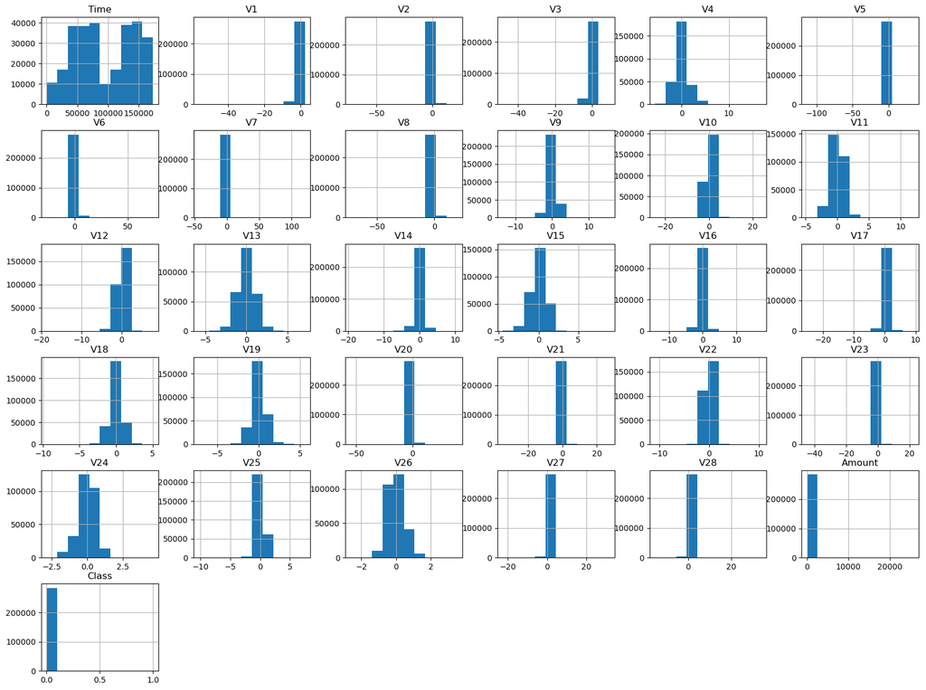

```python
df.hist(figsize=(20,15))
```

Most data is densely distributed (due to standardization).

However, we can plot time by converting seconds to hours, dividing it by 3600, and then plotting the frequency of transactions - as we can see, most of them took place during the day.

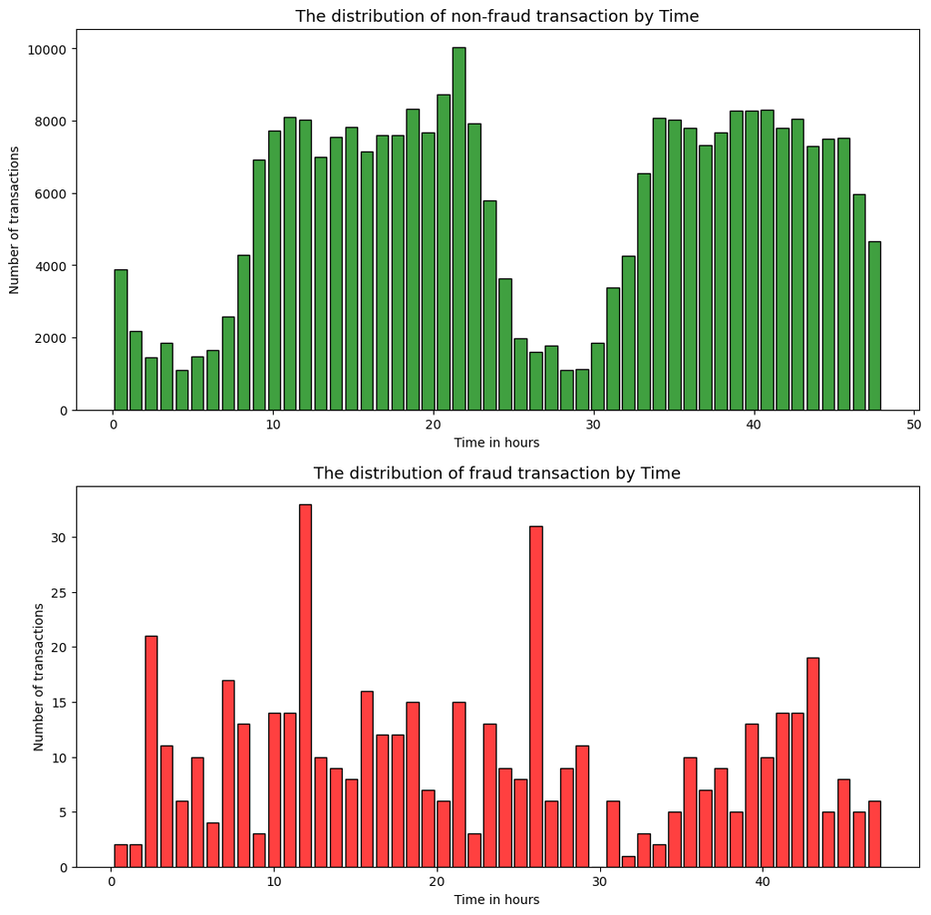

```python
f, (ax1, ax2) = plt.subplots(2, figsize=(12,12))


sns.histplot(x = df.loc[df['Class'] == 0]['Time']/3600, shrink=0.8, color='green', bins = 50, ax = ax1)
ax1.set_xlabel('Time in hours')
ax1.set_ylabel('Number of transactions')
ax1.set_title('The distribution of non-fraud transaction by Time', fontsize = 13)

sns.histplot(x = df.loc[df['Class'] == 1]['Time']/3600, shrink=0.8, color='red', bins = 50, ax = ax2)
ax2.set_xlabel('Time in hours')
ax2.set_ylabel('Number of transactions')
ax2.set_title('The distribution of fraud transaction by Time', fontsize = 13)
```

As we can see above, the probability of Fraud Transactions during a day is similar to that at night - unlike for non-fraud transactions, where most of it are done during daylight.\ However, we have a huge imbalance in our dataset for our fraud/non-fraud class - so it still can be result of small sample of Fraud transactions.

```python
df['Class'].value_counts()
```

```
Class
0    284315
1       492
Name: count, dtype: int64
```

```
[(0.0, 2000.0)]
```

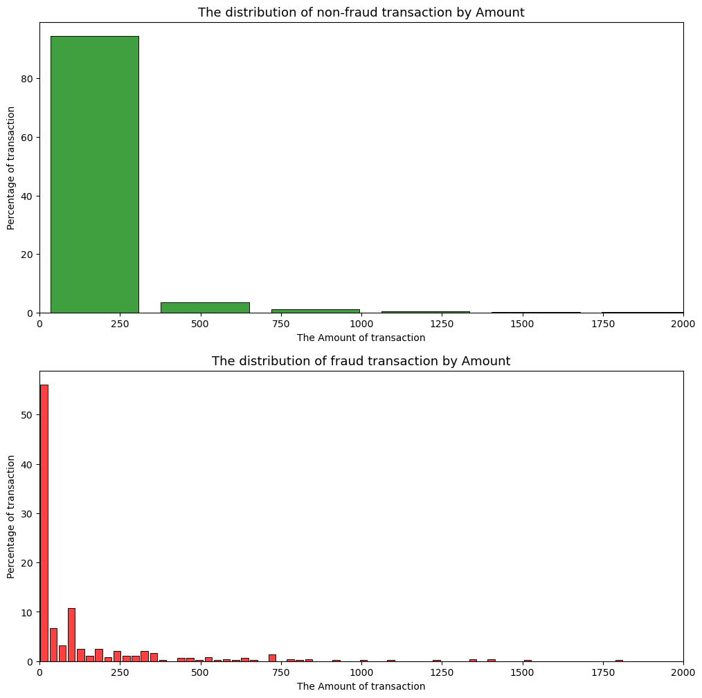

```python
f, (ax1, ax2) = plt.subplots(2, figsize=(12,12))


sns.histplot(x = df.loc[df['Class'] == 0]['Amount'], shrink=0.8, color='green', stat='percent', bins = 75, ax = ax1)
ax1.set_xlabel('The Amount of transaction')
ax1.set_ylabel('Percentage of transaction')
ax1.set_title('The distribution of non-fraud transaction by Amount', fontsize = 13)
ax1.set(xlim=(0, 2000))

sns.histplot(x = df.loc[df['Class'] == 1]['Amount'], shrink=0.8, color='red', stat='percent', bins = 75, ax = ax2)
ax2.set_xlabel('The Amount of transaction')
ax2.set_ylabel('Percentage of transaction')
ax2.set_title('The distribution of fraud transaction by Amount', fontsize = 13)
ax2.set(xlim=(0, 2000))
```

We standardize the only two variables that was left: Amount and Time

```python
scaler = StandardScaler()
df['Scaled Time']= scaler.fit_transform(df['Time'].values.reshape(-1,1))
df['Scaled Amount']= scaler.fit_transform(df['Amount'].values.reshape(-1,1))
df = df.drop(columns = ['Time', 'Amount'])
```

And of course we will checking for missing data:

```python
pd.DataFrame({'Column Names': df.columns, 'number of missing data': df.isnull().sum()}).sort_values(by = 'number of missing data', ascending=False)
```

|  | Column Names | number of missing data |
| --- | --- | --- |
| V1 | V1 | 0 |
| V17 | V17 | 0 |
| Scaled Time | Scaled Time | 0 |
| Class | Class | 0 |
| V28 | V28 | 0 |
| V27 | V27 | 0 |
| V26 | V26 | 0 |
| V25 | V25 | 0 |
| V24 | V24 | 0 |
| V23 | V23 | 0 |
| V22 | V22 | 0 |
| V21 | V21 | 0 |
| V20 | V20 | 0 |
| V19 | V19 | 0 |
| V18 | V18 | 0 |
| V16 | V16 | 0 |
| V2 | V2 | 0 |
| V15 | V15 | 0 |
| V14 | V14 | 0 |
| V13 | V13 | 0 |
| V12 | V12 | 0 |
| V11 | V11 | 0 |
| V10 | V10 | 0 |
| V9 | V9 | 0 |
| V8 | V8 | 0 |
| V7 | V7 | 0 |
| V6 | V6 | 0 |
| V5 | V5 | 0 |
| V4 | V4 | 0 |
| V3 | V3 | 0 |
| Scaled Amount | Scaled Amount | 0 |

### Random undersampling:

We will split dataframe to try catch frauds transactions, while dealing with massive number of non-fraud transactions

```python
df_frauds = df.loc[df['Class'] == 1]
df_standards = df.loc[df['Class'] == 0]
```

```python
df_standards_sample = df_standards.sample(n = df_frauds.shape[0]*3, random_state=17)
df_sample = pd.concat([df_standards_sample,df_frauds])
```

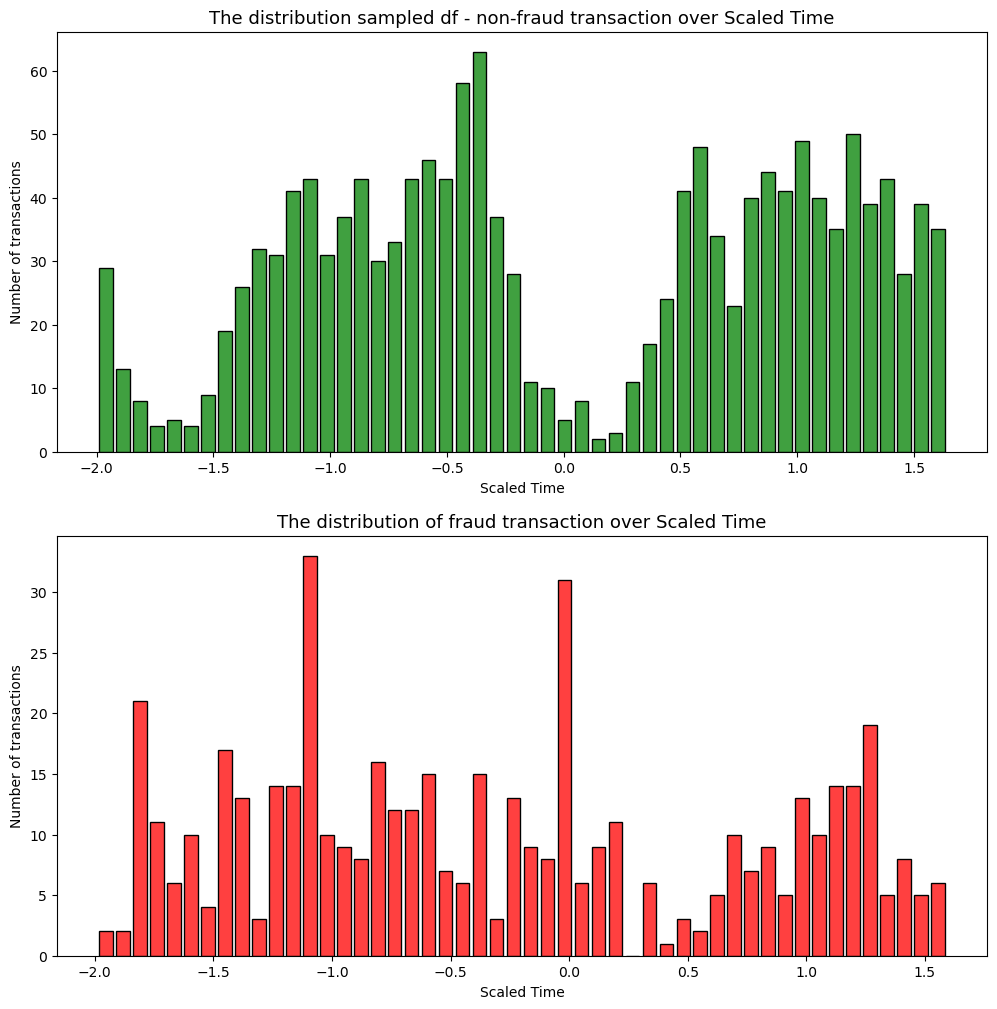

```python
f, (ax1, ax2) = plt.subplots(2, figsize=(12,12))


sns.histplot(x = df_sample.loc[df_sample['Class'] == 0]['Scaled Time'], shrink=0.8, color='green', bins = 50, ax = ax1)
ax1.set_xlabel('Scaled Time')
ax1.set_ylabel('Number of transactions')
ax1.set_title('The distribution sampled df - non-fraud transaction over Scaled Time', fontsize = 13)

sns.histplot(x = df_sample.loc[df_sample['Class'] == 1]['Scaled Time'], shrink=0.8, color='red', bins = 50, ax = ax2)
ax2.set_xlabel('Scaled Time')
ax2.set_ylabel('Number of transactions')
ax2.set_title('The distribution of fraud transaction over Scaled Time', fontsize = 13)
```

Naturally, Scaled Time didn't change the distribution for Fraud Transactions. What is more, the Sampled DF have the same pattern for non-fraud Transaction distribution.

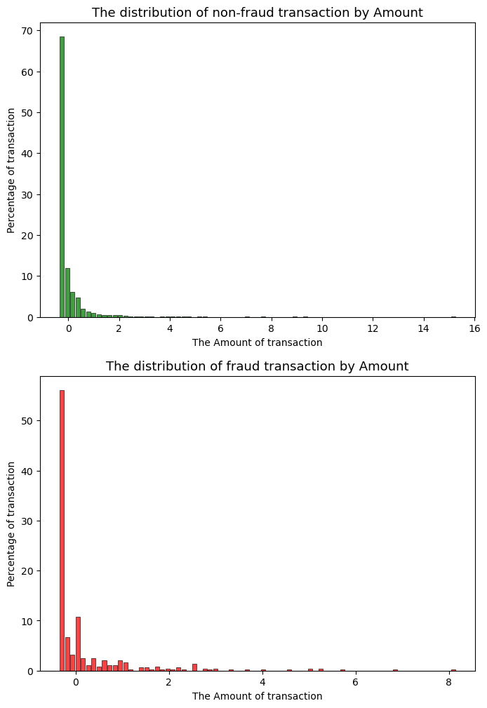

```python
f, (ax1, ax2) = plt.subplots(2, figsize=(8,12))


sns.histplot(x = df_sample.loc[df_sample['Class'] == 0]['Scaled Amount'], shrink=0.8, color='green', stat='percent', bins = 75, ax = ax1)
ax1.set_xlabel('The Amount of transaction')
ax1.set_ylabel('Percentage of transaction')
ax1.set_title('The distribution of non-fraud transaction by Amount', fontsize = 13)

sns.histplot(x = df_sample.loc[df_sample['Class'] == 1]['Scaled Amount'], shrink=0.8, color='red', stat='percent', bins = 75, ax = ax2)
ax2.set_xlabel('The Amount of transaction')
ax2.set_ylabel('Percentage of transaction')
ax2.set_title('The distribution of fraud transaction by Amount', fontsize = 13)
```

For the Sampled DF we have much more similar distriibution between non-fraud and fraud transactions for the variable 'Scaled Amount' - however still we manage to catch original pattern.

## Correlation

As we will see, correlation plot is pointless without sampling tha data. It will be really useful in next version of the notebook, when we will apply outlier detection.

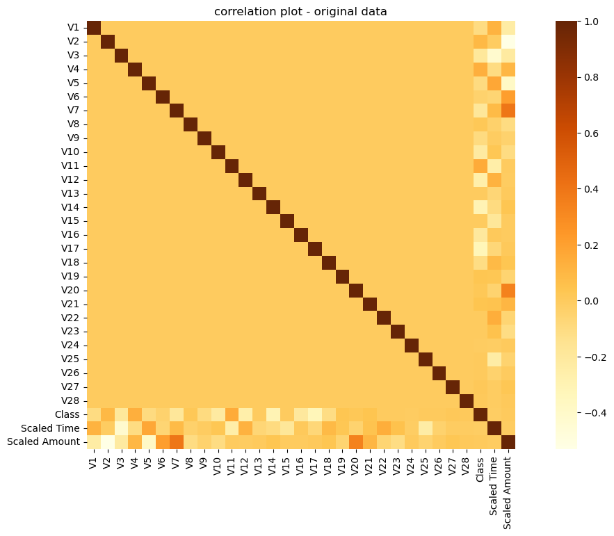

```python
plt.figure(figsize=(15,8))
sns.heatmap(df.corr(), square=True, cmap = 'YlOrBr').set_title('correlation plot - original data')
```

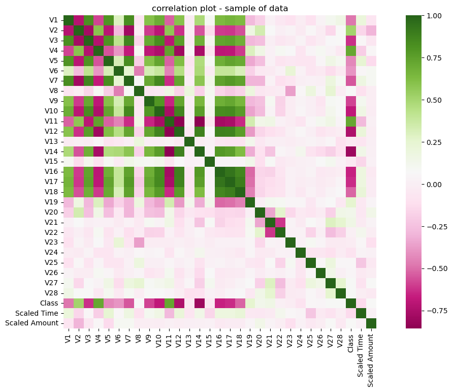

```python
plt.figure(figsize=(15,8))
sns.heatmap(df_sample.corr(), square=True, cmap="PiYG").set_title('correlation plot - sample of data')
```

As we see there are few strongly positive and negative corelated variables:

```python
print("top negative correlated values are:\n", df_sample.corr()['Class'].sort_values().head(5))
print("top positive correlated values are:\n", df_sample.corr()['Class'].sort_values().tail(6))
```

```
top negative correlated values are:
 V14   -0.798810
V12   -0.744972
V10   -0.685675
V16   -0.658028
V17   -0.632222
Name: Class, dtype: float64
top positive correlated values are:
 V21      0.156646
V19      0.255606
V2       0.510917
V11      0.720833
V4       0.721832
Class    1.000000
Name: Class, dtype: float64
```

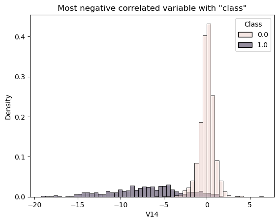

```python
sns.histplot(x= df['V14'], hue = df_sample['Class'], bins = 55, stat="density").set_title('Most negative correlated variable with "class"')
```

# PCA and t-SNE

We will try to plot our data by using dimensionality reduction and ensure that data combination (which we will done by Autoencoder) could be useful in this classification problem.

```python
df_X = df_sample.drop(columns={'Class'})
df_y = df_sample['Class']
```

### Perform PCA and TSNE on only 2 standarized variable

Information about Data stated that whole DF is standardized except column 'Amount' and 'Time', which we standarized at the begging - however, as we sampled from DF other columns will have diffrent mean and std.

```python
pca = PCA(n_components=2, random_state=44)
X_pca_two_standarized = pca.fit_transform(df_X)
print('Explained variance ratio for two components:',[round(x,2) for x in pca.explained_variance_ratio_])
```

```
Explained variance ratio for two components: [0.65, 0.09]
```

```python
tsne = TSNE(n_components=2, random_state=44)
X_tsne_two_standarized = tsne.fit_transform(df_X)
```

### Perform PCA and TSNE on standarized Data Frame

Since we sampled from a normal distribution (0,1), the Central Limit Theorem implies that we will most likely have a mean similar to the original distribution - this will have the highest probability. But it still won't be perfect enough for us.

```python
df_mean = pd.concat([round(df.drop(columns = 'Class').mean(),5),round(df_X.mean(),5)], axis = 1).rename(columns = {0:'original', 1:'sample'})
df_mean['substract'] = df_mean['original'] - df_mean['sample']
df_mean.head()
```

|  | original | sample | substract |
| --- | --- | --- | --- |
| V1 | 0.0 | -1.19172 | 1.19172 |
| V2 | 0.0 | 0.97413 | -0.97413 |
| V3 | -0.0 | -1.73584 | 1.73584 |
| V4 | 0.0 | 1.14788 | -1.14788 |
| V5 | 0.0 | -0.76025 | 0.76025 |

As we can see, there is a significant difference in the mean between the sample DF and the original one - another example of what exactly the Central Limit Theorem state for. More specifically, this ensures that the average of the sample means will be similar to the original mean - once we select a large enough sample - but it does not ensure that the distribution will be identical to that of the original population.

That's why we will perform PCA and TSNE on transformed data:

```python
scaler = StandardScaler()
df_X_all_standarized = scaler.fit_transform(df_X)
```

```python
pca = PCA(n_components=2, random_state=44)
X_pca_all_standarized = pca.fit_transform(df_X_all_standarized)
print('Explained variance ratio for two components:',[round(x,2) for x in pca.explained_variance_ratio_])
```

```
Explained variance ratio for two components: [0.36, 0.09]
```

```python
tsne = TSNE(n_components=2, random_state=44)
X_tsne_all_standarized = tsne.fit_transform(X_pca_all_standarized)
```

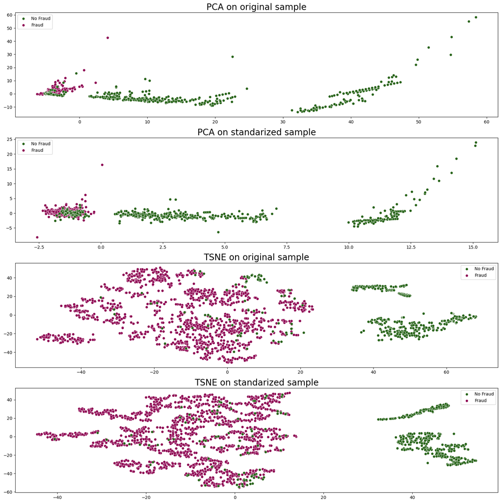

```python
f, (ax1, ax2, ax3, ax4) = plt.subplots(4, figsize=(20,20))


sns.scatterplot(x = X_pca_two_standarized[:,0], y = X_pca_two_standarized[:,1], c = (df_y == 0), cmap ="PiYG", label = 'No Fraud', ax = ax1)
sns.scatterplot(x = X_pca_two_standarized[:,0], y = X_pca_two_standarized[:,1], c = (df_y == 1), cmap ="PiYG", label = 'Fraud', ax = ax1)
ax1.set_title('PCA on original sample', fontsize = 20)

sns.scatterplot(x = X_pca_all_standarized[:,0], y = X_pca_all_standarized[:,1], c = (df_y == 0), cmap ="PiYG", label = 'No Fraud', ax = ax2)
sns.scatterplot(x = X_pca_all_standarized[:,0], y = X_pca_all_standarized[:,1], c = (df_y == 1), cmap ="PiYG", label = 'Fraud', ax = ax2)
ax2.set_title('PCA on standarized sample', fontsize = 20)

sns.scatterplot(x = X_tsne_two_standarized[:,0], y = X_tsne_two_standarized[:,1], c = (df_y == 0), cmap ="PiYG", label = 'No Fraud', ax = ax3)
sns.scatterplot(x = X_tsne_two_standarized[:,0], y = X_tsne_two_standarized[:,1], c = (df_y == 1), cmap ="PiYG", label = 'Fraud', ax = ax3)
ax3.set_title('TSNE on original sample', fontsize = 20)

sns.scatterplot(x = X_tsne_all_standarized[:,0], y = X_tsne_all_standarized[:,1], c = (df_y == 0), cmap ="PiYG", label = 'No Fraud', ax = ax4)
sns.scatterplot(x = X_tsne_all_standarized[:,0], y = X_tsne_all_standarized[:,1], c = (df_y == 1), cmap ="PiYG", label = 'Fraud', ax = ax4)
ax4.set_title('TSNE on standarized sample', fontsize = 20)

plt.legend(labels = ["No Fraud",'Fraud'], loc = 'best')
```

As we can see, there is a significant difference between the two methods used in this dataset. Although in both cases we can see the differences between fraud transactions and non-fraud transactions - the TSNE algorithm performs better for our dataset. Our standardization on sampled Data Frame, especially for TSNE, helped visualize 2 groups of non-fraud transactions and also increased the density of fraud transactions. The bad news is that there are certainly some outliers among non-fraudulent transactions, but the good news is that we can confidently predict which transaction may be considered as a fraud.

# Autoencoder

We will use two architecture of Autoencoders:

- Vanilla Autoencoder
- Sparse Autoencoder

```python
df_standards_sample = df_standards.sample(n = df_frauds.shape[0]*4, random_state=22)
df_standards_sample = df_standards_sample.drop(columns='Class')
```

# Vanilla Autoencoder

Following for me the most the most understandable definition:\ The most basic type of autoencoder, which consists of a decoder network that reconstructs the input from the compressed representation after the input has been compressed by an encoder network.

```python
# input layer
input_layer = Input(shape=(df_standards_sample.shape[1],))

# encoder network
encoded = Dense(30, activation='elu')(input_layer)
encoded = Dense(25, activation='relu')(encoded)
encoded = Dense(20, activation='tanh')(encoded)
encoded = Dense(15, activation='elu')(encoded)
encoded = Dense(10, activation='relu')(encoded)
encoded = Dense(5, activation='tanh')(encoded) # bottleneck


# decoder network
decoded = Dense(10, activation='tanh')(encoded)
decoded = Dense(15, activation='elu')(decoded)
decoded = Dense(20, activation='tanh')(decoded)
decoded = Dense(25, activation='relu')(decoded)
decoded = Dense(30, activation='tanh')(decoded)

# output layer
output_layer = Dense(df_standards_sample.shape[1], activation='relu')(decoded)

# Early Stop
EarlyStop = EarlyStopping(monitor='accuracy', patience=25)
```

```python
autoencoder = Model(input_layer, output_layer)
autoencoder.compile(optimizer="adam", metrics=['accuracy'], loss="mse")
autoencoder.summary()
```

```
Model: "model_1"
_________________________________________________________________
 Layer (type)                Output Shape              Param #
=================================================================
 input_2 (InputLayer)        [(None, 30)]              0

 dense_12 (Dense)            (None, 30)                930

 dense_13 (Dense)            (None, 25)                775

 dense_14 (Dense)            (None, 20)                520

 dense_15 (Dense)            (None, 15)                315

 dense_16 (Dense)            (None, 10)                160

 dense_17 (Dense)            (None, 5)                 55

 dense_18 (Dense)            (None, 10)                60

 dense_19 (Dense)            (None, 15)                165

 dense_20 (Dense)            (None, 20)                320

 dense_21 (Dense)            (None, 25)                525

 dense_22 (Dense)            (None, 30)                780

 dense_23 (Dense)            (None, 30)                930

=================================================================
Total params: 5,535
Trainable params: 5,535
Non-trainable params: 0
_________________________________________________________________
```

```python
history = autoencoder.fit(df_standards_sample, df_standards_sample, batch_size = 256, epochs = 500, shuffle = True, validation_split = 0.20, callbacks = [EarlyStop])
```

We see below that the accuracy for detecting non-fraud transactions start to stabilize around 70+ epoch

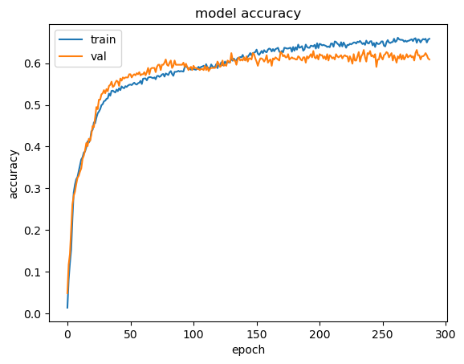

```python
plt.plot(history.history['accuracy'])
plt.plot(history.history['val_accuracy'])
plt.title('model accuracy')
plt.ylabel('accuracy')
plt.xlabel('epoch')
plt.legend(['train', 'val'], loc='upper left')
plt.show()
```

Saving the encoder part of our autoencoder - as we have 6 encoder layers, we will take first 6

```python
hidden_representation = Sequential()
hidden_representation.add(autoencoder.layers[0])
hidden_representation.add(autoencoder.layers[1])
hidden_representation.add(autoencoder.layers[2])
hidden_representation.add(autoencoder.layers[3])
hidden_representation.add(autoencoder.layers[4])
hidden_representation.add(autoencoder.layers[5])
```

Creating test sets, on which we will predict our model (it is slight bigger then original sample DF)

```python
df_standards_sample_test = df_standards.sample(n = df_frauds.shape[0]*5, random_state=22)
df_standards_sample_test = df_standards_sample_test.drop(columns='Class')
df_frauds_test = df_frauds.drop(columns='Class')
norm_hid_rep = hidden_representation.predict(df_standards_sample_test)
fraud_hid_rep = hidden_representation.predict(df_frauds_test)
```

```python
encoder_X_vanilla = np.append(norm_hid_rep, fraud_hid_rep, axis = 0)
y_non_fraud = np.zeros(norm_hid_rep.shape[0])
y_fraud = np.ones(fraud_hid_rep.shape[0])
encoded_y_vanilla = np.append(y_non_fraud, y_fraud)
```

## Logistic Regression, Random Forest Classifier, XGBoost Classifier and SVM Classifier

```python
X_train_1, X_test_1, y_train_1, y_test_1 = train_test_split(encoder_X_vanilla, encoded_y_vanilla, test_size=0.3, random_state=22)
```

```python
# Logistic Regression for Vanilla Autoencoder
lr_1 = LogisticRegression(random_state=22)

# Random Forest for Vanilla Autoencoder
rf_1 = RandomForestClassifier(random_state=22)


# XGBoost for Vanilla Autoencoder
XGBc_1 = GradientBoostingClassifier(random_state=22)

# Support vector machines
SVC_1 = SVC(random_state=22)
```

```python
grid_dict = {lr_1:{ 'C':[0.001, 0.01, 0.1, 1, 10, 100, 1000],
                    'penalty':['l1','l2']},
            rf_1:{  'min_samples_split': [2, 5, 10],
                    'n_estimators':[200, 400, 600, 800, 1000],
                    'max_depth': [5, 10, 15, 20, 25,None]},
            XGBc_1:{'max_depth': [5, 10, 15, 20, 25,None],
                    'n_estimators':[200, 400, 600, 800, 1000],
                    'learning_rate': [0.01,0.05, 0.1]},
            SVC_1:{ 'C': [0.1, 1, 10, 100, 1000],
                    'gamma': [1, 0.1, 0.01, 0.001, 0.0001],
                    'kernel': ['rbf','linear']}}
```

### Hyperparameters tuning and Cross Validation

```python
# dict_grid_parm = {}
# for model_type, param_grid in grid_dict.items():
#     search_1 = HalvingGridSearchCV(model_type, param_grid, random_state=22, scoring='roc_auc').fit(X_train_1, y_train_1)
#     dict_grid_parm[model_type]=search_1.best_params_
```

{LogisticRegression(): {'C': 0.1, 'penalty': 'l2'},\ RandomForestClassifier(): {'max_depth': 10, 'min_samples_split': 5, 'n_estimators': 800},\ GradientBoostingClassifier(): {'learning_rate': 0.05, 'max_depth': 15, 'n_estimators': 200},\ SVC(): {'C': 100, 'gamma': 0.1, 'kernel': 'rbf'}}

```python
# Logistic Regression for Vanilla Autoencoder
lr_1 = LogisticRegression(C= 0.1,
                           penalty = 'l2',
                           random_state=22)


# Random Forest for Vanilla Autoencoder
rf_1 = RandomForestClassifier(max_depth = 10,
                              min_samples_split = 5,
                              n_estimators = 800,
                              random_state=22)


# XGBoost for Vanilla Autoencoder
XGBc_1 = GradientBoostingClassifier(learning_rate = 0.05,
                                    max_depth = 15,
                                    n_estimators = 200,
                                    random_state=22)

# Support vector machines for Vanilla Autoencoder
SVC_1 = SVC(C = 100,
            gamma = 0.1,
            kernel = 'rbf',
            random_state=22)
```

```python
models_dict = {'Logistic Regression':lr_1,
               'Random Forest Classifier':rf_1,
               'Gradient Boosting Classifier':XGBc_1,
               'Support vector machines':SVC_1}


for name, model_type in models_dict.items():
    print(name, cross_val_score(model_type, X_train_1, y_train_1, cv=5, scoring='roc_auc').mean(),'roc_auc')
```

```
Logistic Regression 0.8798770059745002 roc_auc
Random Forest Classifier 0.9547134995320793 roc_auc
Gradient Boosting Classifier 0.863996055933254 roc_auc
Support vector machines 0.9469872820979626 roc_auc
```

```python
# Logistic Regression for Vanilla Autoencoder
lr_1.fit(X_train_1, y_train_1)
pred_y_LR_1 = lr_1.predict(X_test_1)

# Random Forest for Vanilla Autoencoder
rf_1.fit(X_train_1, y_train_1)
pred_y_RF_1 = rf_1.predict(X_test_1)

# XGBoost for Vanilla Autoencoder
XGBc_1.fit(X_train_1, y_train_1)
pred_y_XGB_1 = XGBc_1.predict(X_test_1)

# Support vector machines for Vanilla Autoencoder
SVC_1.fit(X_train_1, y_train_1)
pred_y_SVC_1 = SVC_1.predict(X_test_1)
```

### Results of models

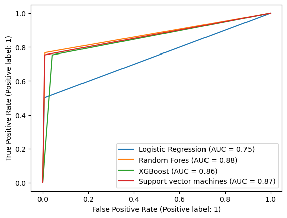

```python
fig, ax = plt.subplots()
RocCurveDisplay.from_predictions(y_test_1, pred_y_LR_1, ax=ax, name = 'Logistic Regression')
RocCurveDisplay.from_predictions(y_test_1, pred_y_RF_1, ax=ax, name = 'Random Fores')
RocCurveDisplay.from_predictions(y_test_1, pred_y_XGB_1, ax=ax, name = 'XGBoost')
RocCurveDisplay.from_predictions(y_test_1, pred_y_SVC_1, ax=ax, name = 'Support vector machines')
plt.show()
```

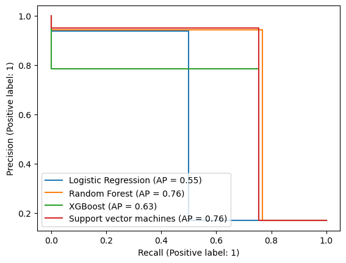

```python
fig, ax = plt.subplots()
PrecisionRecallDisplay.from_predictions(y_test_1, pred_y_LR_1, ax=ax, name = 'Logistic Regression')
PrecisionRecallDisplay.from_predictions(y_test_1, pred_y_RF_1, ax=ax, name = 'Random Forest')
PrecisionRecallDisplay.from_predictions(y_test_1, pred_y_XGB_1, ax=ax, name = 'XGBoost')
PrecisionRecallDisplay.from_predictions(y_test_1, pred_y_SVC_1, ax=ax, name = 'Support vector machines')
plt.show()
```

```python
pred_dict = {'Logistic Regression':pred_y_LR_1,
               'Random Forest Classifier':pred_y_RF_1,
               'Gradient Boosting Classifier':pred_y_XGB_1,
               'Support vector machines':pred_y_SVC_1}

for name, pred in pred_dict.items():
    print(f"Confusion Matrix of {name} for Vanilla Autoencoder:")
    print(confusion_matrix(y_test_1, pred))
    print ("")
    print (f"Classification Report of {name} for Vanilla Autoencoder: ")
    print (classification_report(y_test_1, pred))
```

```
Confusion Matrix of Logistic Regression for Vanilla Autoencoder:
[[731   5]
 [ 75  75]]

Classification Report of Logistic Regression for Vanilla Autoencoder:
              precision    recall  f1-score   support

         0.0       0.91      0.99      0.95       736
         1.0       0.94      0.50      0.65       150

    accuracy                           0.91       886
   macro avg       0.92      0.75      0.80       886
weighted avg       0.91      0.91      0.90       886

Confusion Matrix of Random Forest Classifier for Vanilla Autoencoder:
[[729   7]
 [ 35 115]]

Classification Report of Random Forest Classifier for Vanilla Autoencoder:
              precision    recall  f1-score   support

         0.0       0.95      0.99      0.97       736
         1.0       0.94      0.77      0.85       150

    accuracy                           0.95       886
   macro avg       0.95      0.88      0.91       886
weighted avg       0.95      0.95      0.95       886

Confusion Matrix of Gradient Boosting Classifier for Vanilla Autoencoder:
[[705  31]
 [ 37 113]]

Classification Report of Gradient Boosting Classifier for Vanilla Autoencoder:
              precision    recall  f1-score   support

         0.0       0.95      0.96      0.95       736
         1.0       0.78      0.75      0.77       150

    accuracy                           0.92       886
   macro avg       0.87      0.86      0.86       886
weighted avg       0.92      0.92      0.92       886

Confusion Matrix of Support vector machines for Vanilla Autoencoder:
[[730   6]
 [ 37 113]]

Classification Report of Support vector machines for Vanilla Autoencoder:
              precision    recall  f1-score   support

         0.0       0.95      0.99      0.97       736
         1.0       0.95      0.75      0.84       150

    accuracy                           0.95       886
   macro avg       0.95      0.87      0.91       886
weighted avg       0.95      0.95      0.95       886
```

# Sparse Autoencoders

One more time following for me the most understandable definition:\ A Sparse Autoencoder is a type of autoencoder that employs sparsity to achieve an information bottleneck. Specifically the loss function is constructed so that activations are penalized within a layer.

```python
## input layer
input_layer = Input(shape=(df_standards_sample.shape[1],))

## encoder network
encoded = Dense(64, activation='elu', activity_regularizer=regularizers.l1(0.0001))(input_layer)
encoded = Dense(32, activation='tanh', activity_regularizer=regularizers.l1(0.0001))(encoded)
encoded = Dense(16, activation='elu', activity_regularizer=regularizers.l1(0.0001))(encoded)
encoded = Dense(8, activation='relu', activity_regularizer=regularizers.l1(0.0001))(encoded)


## decoder network part
decoded = Dense(16, activation='tanh')(encoded)
decoded = Dense(32, activation='elu')(decoded)
decoded = Dense(64, activation='tanh')(decoded)

## output layer
output_layer = Dense(df_standards_sample.shape[1], activation='relu')(decoded)

EarlyStop = EarlyStopping(monitor='accuracy', patience=25)
```

```python
autoencoder = Model(input_layer, output_layer)
autoencoder.compile(optimizer="adam", metrics=['accuracy'], loss="mse")
autoencoder.summary()
```

```
Model: "model_2"
_________________________________________________________________
 Layer (type)                Output Shape              Param #
=================================================================
 input_3 (InputLayer)        [(None, 30)]              0

 dense_24 (Dense)            (None, 64)                1984

 dense_25 (Dense)            (None, 32)                2080

 dense_26 (Dense)            (None, 16)                528

 dense_27 (Dense)            (None, 8)                 136

 dense_28 (Dense)            (None, 16)                144

 dense_29 (Dense)            (None, 32)                544

 dense_30 (Dense)            (None, 64)                2112

 dense_31 (Dense)            (None, 30)                1950

=================================================================
Total params: 9,478
Trainable params: 9,478
Non-trainable params: 0
_________________________________________________________________
```

```python
history = autoencoder.fit(df_standards_sample, df_standards_sample, batch_size = 256, epochs = 500, shuffle = True,
                           validation_split = 0.20, callbacks = [EarlyStop])
```

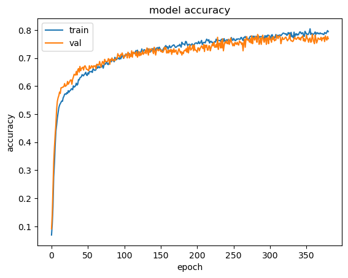

```python
plt.plot(history.history['accuracy'])
plt.plot(history.history['val_accuracy'])
plt.title('model accuracy')
plt.ylabel('accuracy')
plt.xlabel('epoch')
plt.legend(['train', 'val'], loc='upper left')
plt.show()
```

Saving the encoder part of our autoencoder - as we have 4 encoder layers, we will take first 4

```python
hidden_representation = Sequential()
hidden_representation.add(autoencoder.layers[0])
hidden_representation.add(autoencoder.layers[1])
hidden_representation.add(autoencoder.layers[2])
hidden_representation.add(autoencoder.layers[3])
```

Creating test sets, on which we will predict our model (it is slight bigger then original sample DF)

```python
df_standards_sample_test = df_standards.sample(n = df_frauds.shape[0]*5, random_state=22)
df_standards_sample_test = df_standards_sample_test.drop(columns='Class')
df_frauds_test = df_frauds.drop(columns='Class')
norm_hid_rep = hidden_representation.predict(df_standards_sample_test)
fraud_hid_rep = hidden_representation.predict(df_frauds_test)
```

```python
encoder_X_sparse = np.append(norm_hid_rep, fraud_hid_rep, axis = 0)
y_non_fraud = np.zeros(norm_hid_rep.shape[0])
y_fraud = np.ones(fraud_hid_rep.shape[0])
encoded_y_sparse = np.append(y_non_fraud, y_fraud)
```

## Logistic Regression, Random Forest Classifier, XGBoost Classifier and SVM Classifier

```python
X_train_2, X_test_2, y_train_2, y_test_2 = train_test_split(encoder_X_sparse, encoded_y_sparse, test_size=0.3, random_state=22)
```

```python
# Logistic Regression for Sparse Autoencoder
lr_2 = LogisticRegression(random_state=22)

# Random Forest for Sparse Autoencoder
rf_2 = RandomForestClassifier(random_state=22)


# XGBoost for Sparse Autoencoder
XGBc_2 = GradientBoostingClassifier(random_state=22)

# Support vector machines for Sparse Autoencoder
SVC_2 = SVC(random_state=22)
```

```python
grid_dict_2 = {lr_2:{ 'C':[0.001, 0.01, 0.1, 1, 10, 100, 1000],
                    'penalty':['l1','l2']},
            rf_2:{  'min_samples_split': [2, 5, 10],
                    'n_estimators':[200, 400, 600, 800, 1000],
                    'max_depth': [5, 10, 15, 20, 25,None]},
            XGBc_2:{'max_depth': [5, 10, 15, 20, 25,None],
                    'n_estimators':[200, 400, 600, 800, 1000],
                    'learning_rate': [0.01,0.05, 0.1]},
            SVC_2:{ 'C': [0.1, 1, 10, 100, 1000],
                    'gamma': [1, 0.1, 0.01, 0.001, 0.0001],
                    'kernel': ['rbf','linear']}}
```

### Hyperparameters tuning and Cross Validation

```python
#dict_grid_parm_2 = {}
#for model_type, param_grid in grid_dict_2.items():
#    search_2 = HalvingGridSearchCV(model_type, param_grid, random_state=22, scoring='roc_auc').fit(X_train_2, y_train_2)
#    dict_grid_parm_2[model_type]=search_2.best_params_
```

{LogisticRegression(random_state=22): {'C': 100, 'penalty': 'l2'},\ RandomForestClassifier(random_state=22): {'max_depth': 10, 'min_samples_split': 5, 'n_estimators': 200},\ GradientBoostingClassifier(random_state=22): {'learning_rate': 0.1, 'max_depth': None, 'n_estimators': 800},\ SVC(random_state=22): {'C': 100, 'gamma': 0.1, 'kernel': 'rbf'}}

```python
# Logistic Regression for Sparse Autoencoder
lr_2 = LogisticRegression(C= 100,
                           penalty = 'l2',
                             random_state=22)


# Random Forest for Sparse Autoencoder
rf_2 = RandomForestClassifier(max_depth = 10,
                              min_samples_split = 5,
                              n_estimators = 200,
                              random_state=22)


# XGBoost for Sparse Autoencoder
XGBc_2 = GradientBoostingClassifier(learning_rate = 0.1,
                                    max_depth = None,
                                    n_estimators = 800,
                                    random_state=22)

# Support vector machines for Sparse Autoencoder
SVC_2 = SVC(C = 100,
             gamma = 0.1,
               kernel = 'rbf',
               random_state=22)
```

```python
models_dict = {'Logistic Regression':lr_2,
               'Random Forest Classifier':rf_2,
               'Gradient Boosting Classifier':XGBc_2,
               'Support vector machines':SVC_2}


for name, model_type in models_dict.items():
    print(name, cross_val_score(model_type, X_train_2, y_train_2, cv=5, scoring='roc_auc').mean(),'roc_auc')
```

```
Logistic Regression 0.9647199170988863 roc_auc
Random Forest Classifier 0.967585010851104 roc_auc
Gradient Boosting Classifier 0.9558908752170435 roc_auc
Support vector machines 0.9651119978185733 roc_auc
```

```python
# Logistic Regression for Sparse Autoencoder
lr_2.fit(X_train_2, y_train_2)
pred_y_LR_2 = lr_2.predict(X_test_2)

# Random Forest for Sparse Autoencoder
rf_2.fit(X_train_2, y_train_2)
pred_y_RF_2 = rf_2.predict(X_test_2)

# XGBoost for Sparse Autoencoder
XGBc_2.fit(X_train_2, y_train_2)
pred_y_XGB_2 = XGBc_2.predict(X_test_2)

# Support vector machines for Sparse Autoencoder
SVC_2.fit(X_train_2, y_train_2)
pred_y_SVC_2 = SVC_2.predict(X_test_2)
```

### Results of models

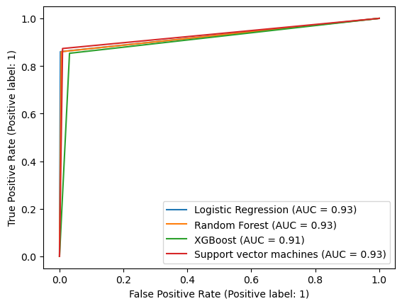

```python
fig, ax = plt.subplots()
RocCurveDisplay.from_predictions(y_test_2, pred_y_LR_2, ax=ax, name = 'Logistic Regression')
RocCurveDisplay.from_predictions(y_test_2, pred_y_RF_2, ax=ax, name = 'Random Forest')
RocCurveDisplay.from_predictions(y_test_2, pred_y_XGB_2, ax=ax, name = 'XGBoost')
RocCurveDisplay.from_predictions(y_test_2, pred_y_SVC_2, ax=ax, name = 'Support vector machines')
plt.show()
```

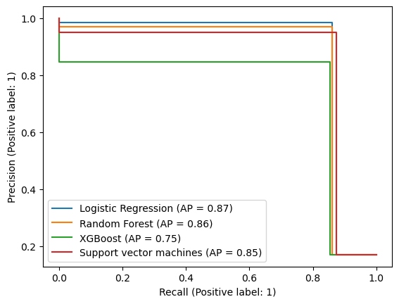

```python
fig, ax = plt.subplots()
PrecisionRecallDisplay.from_predictions(y_test_2, pred_y_LR_2, ax=ax, name = 'Logistic Regression')
PrecisionRecallDisplay.from_predictions(y_test_2, pred_y_RF_2, ax=ax, name = 'Random Forest')
PrecisionRecallDisplay.from_predictions(y_test_2, pred_y_XGB_2, ax=ax, name = 'XGBoost')
PrecisionRecallDisplay.from_predictions(y_test_2, pred_y_SVC_2, ax=ax, name = 'Support vector machines')
plt.show()
```

```python
pred_dict = {'Logistic Regression':pred_y_LR_2,
               'Random Forest Classifier':pred_y_RF_2,
               'Gradient Boosting Classifier':pred_y_XGB_2,
               'Support vector machines':pred_y_SVC_2}

for name, pred in pred_dict.items():
    print(f"Confusion Matrix of {name} for Sparse Autoencoder:")
    print(confusion_matrix(y_test_2, pred))
    print ("")
    print (f"Classification Report of {name} for Sparse Autoencoder: ")
    print (classification_report(y_test_2, pred))
```

```
Confusion Matrix of Logistic Regression for Sparse Autoencoder:
[[734   2]
 [ 21 129]]

Classification Report of Logistic Regression for Sparse Autoencoder:
              precision    recall  f1-score   support

         0.0       0.97      1.00      0.98       736
         1.0       0.98      0.86      0.92       150

    accuracy                           0.97       886
   macro avg       0.98      0.93      0.95       886
weighted avg       0.97      0.97      0.97       886

Confusion Matrix of Random Forest Classifier for Sparse Autoencoder:
[[732   4]
 [ 21 129]]

Classification Report of Random Forest Classifier for Sparse Autoencoder:
              precision    recall  f1-score   support

         0.0       0.97      0.99      0.98       736
         1.0       0.97      0.86      0.91       150

    accuracy                           0.97       886
   macro avg       0.97      0.93      0.95       886
weighted avg       0.97      0.97      0.97       886

Confusion Matrix of Gradient Boosting Classifier for Sparse Autoencoder:
[[713  23]
 [ 22 128]]

Classification Report of Gradient Boosting Classifier for Sparse Autoencoder:
              precision    recall  f1-score   support

         0.0       0.97      0.97      0.97       736
         1.0       0.85      0.85      0.85       150

    accuracy                           0.95       886
   macro avg       0.91      0.91      0.91       886
weighted avg       0.95      0.95      0.95       886

Confusion Matrix of Support vector machines for Sparse Autoencoder:
[[729   7]
 [ 19 131]]

Classification Report of Support vector machines for Sparse Autoencoder:
              precision    recall  f1-score   support

         0.0       0.97      0.99      0.98       736
         1.0       0.95      0.87      0.91       150

    accuracy                           0.97       886
   macro avg       0.96      0.93      0.95       886
weighted avg       0.97      0.97      0.97       886
```

## Now we will plot all TSNE plots - we will add two plots, formed by encoded data

```python
tsne = TSNE(n_components=2, random_state=44)
X_tsne_vanilla = tsne.fit_transform(encoder_X_vanilla)

tsne = TSNE(n_components=2, random_state=44)
X_tsne_sparse = tsne.fit_transform(encoder_X_sparse)
```

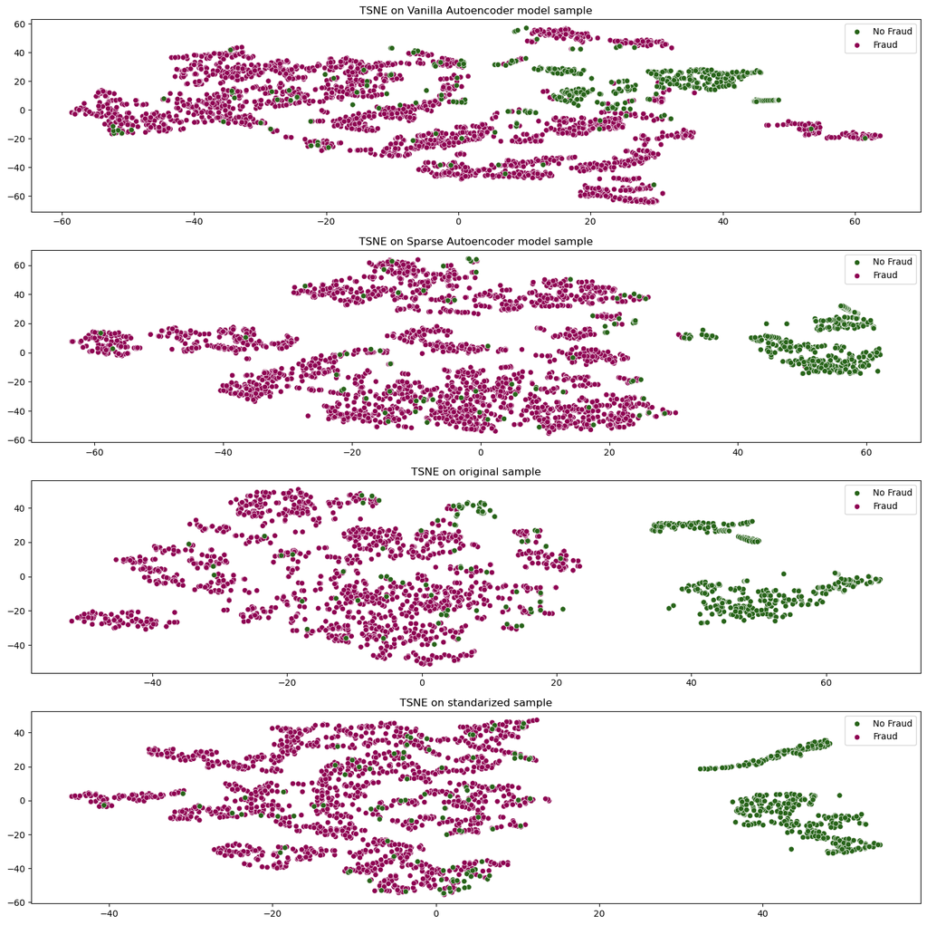

```python
f, (ax1,ax2,ax3,ax4) = plt.subplots(4, figsize=(18,18))


sns.scatterplot(x = X_tsne_vanilla[:,0], y = X_tsne_vanilla[:,1], c = (encoded_y_vanilla == 0), cmap ="PiYG", label = 'No Fraud', ax = ax1)
sns.scatterplot(x = X_tsne_vanilla[:,0], y = X_tsne_vanilla[:,1], c = (encoded_y_vanilla == 1), cmap ="PiYG", label = 'Fraud', ax = ax1)
ax1.set_title('TSNE on Vanilla Autoencoder model sample')

sns.scatterplot(x = X_tsne_sparse[:,0], y = X_tsne_sparse[:,1], c = (encoded_y_sparse == 0), cmap ="PiYG", label = 'No Fraud', ax = ax2)
sns.scatterplot(x = X_tsne_sparse[:,0], y = X_tsne_sparse[:,1], c = (encoded_y_sparse == 1), cmap ="PiYG", label = 'Fraud', ax = ax2)
ax2.set_title('TSNE on Sparse Autoencoder model sample')

sns.scatterplot(x = X_tsne_two_standarized[:,0], y = X_tsne_two_standarized[:,1], c = (df_y == 0), cmap ="PiYG", label = 'No Fraud', ax = ax3)
sns.scatterplot(x = X_tsne_two_standarized[:,0], y = X_tsne_two_standarized[:,1], c = (df_y == 1), cmap ="PiYG", label = 'Fraud', ax = ax3)
ax3.set_title('TSNE on original sample')

sns.scatterplot(x = X_tsne_all_standarized[:,0], y = X_tsne_all_standarized[:,1], c = (df_y == 0), cmap ="PiYG", label = 'No Fraud', ax = ax4)
sns.scatterplot(x = X_tsne_all_standarized[:,0], y = X_tsne_all_standarized[:,1], c = (df_y == 1), cmap ="PiYG", label = 'Fraud', ax = ax4)
ax4.set_title('TSNE on standarized sample')
```

# Prediction with models on undersampled data frame

```python
X = df_sample.drop(columns = 'Class')
y = df_sample['Class']
```

```python
X_train_3, X_test_3, y_train_3, y_test_3 = train_test_split(X, y, test_size=0.3, random_state=22)
```

```python
# Logistic Regression for Sparse Autoencoder
lr_3 = LogisticRegression(random_state=22)

# Random Forest for Sparse Autoencoder
rf_3 = RandomForestClassifier(random_state=22)


# XGBoost for Sparse Autoencoder
XGBc_3 = GradientBoostingClassifier(random_state=22)

# Support vector machines for Sparse Autoencoder
SVC_3 = SVC(random_state=22)
```

```python
grid_dict_3 = {lr_3:{ 'C':[0.001, 0.01, 0.1, 1, 10, 100, 1000],
                    'penalty':['l1','l2']},
            rf_3:{  'min_samples_split': [2, 5, 10],
                    'n_estimators':[200, 400, 600, 800, 1000],
                    'max_depth': [5, 10, 15, 20, 25,None]},
            XGBc_3:{'max_depth': [5, 10, 15, 20, 25,None],
                    'n_estimators':[200, 400, 600, 800, 1000],
                    'learning_rate': [0.01,0.05, 0.1]},
            SVC_3:{ 'C': [0.1, 1, 10, 100, 1000],
                    'gamma': [1, 0.1, 0.01, 0.001, 0.0001],
                    'kernel': ['rbf','linear']}}
```

### Hyperparameters tuning and Cross Validation

```python
#dict_grid_parm_3 = {}
#for model_type, param_grid in grid_dict_3.items():
#    search_3 = HalvingGridSearchCV(model_type, param_grid, random_state=22, scoring='roc_auc').fit(X_train_3, y_train_3)
#    dict_grid_parm_3[model_type]=search_3.best_params_
```

{LogisticRegression(random_state=22): {'C': 0.001, 'penalty': 'l2'},\ RandomForestClassifier(random_state=22): {'max_depth': 15, 'min_samples_split': 5, 'n_estimators': 1000},\ GradientBoostingClassifier(random_state=22): {'learning_rate': 0.05, 'max_depth': 5, 'n_estimators': 800},\ SVC(random_state=22): {'C': 10, 'gamma': 0.001, 'kernel': 'rbf'}}

```python
# Logistic Regression for Sparse Autoencoder
lr_3 = LogisticRegression(C= 0.001,
                           penalty = 'l2',
                             random_state=22)


# Random Forest for Sparse Autoencoder
rf_3 = RandomForestClassifier(max_depth = 15,
                              min_samples_split = 5,
                              n_estimators = 1000,
                              random_state=22)


# XGBoost for Sparse Autoencoder
XGBc_3 = GradientBoostingClassifier(learning_rate = 0.05,
                                    max_depth = 5,
                                    n_estimators = 800,
                                    random_state=22)

# Support vector machines for Sparse Autoencoder
SVC_3 = SVC(C = 10,
             gamma = 0.001,
               kernel = 'rbf',
               random_state=22)
```

```python
models_dict = {'Logistic Regression':lr_3,
               'Random Forest Classifier':rf_3,
               'Gradient Boosting Classifier':XGBc_3,
               'Support vector machines':SVC_3}


for name, model_type in models_dict.items():
    print(name, cross_val_score(model_type, X_train_3, y_train_3, cv=5, scoring='roc_auc').mean(),'roc_auc')
```

```
Logistic Regression 0.9819941717176321 roc_auc
Random Forest Classifier 0.9784802969443192 roc_auc
Gradient Boosting Classifier 0.9774830331189399 roc_auc
Support vector machines 0.9817868656754467 roc_auc
```

```python
# Logistic Regression for Sparse Autoencoder
lr_3.fit(X_train_3, y_train_3)
pred_y_LR_3 = lr_3.predict(X_test_3)

# Random Forest for Sparse Autoencoder
rf_3.fit(X_train_3, y_train_3)
pred_y_RF_3 = rf_3.predict(X_test_3)

# XGBoost for Sparse Autoencoder
XGBc_3.fit(X_train_3, y_train_3)
pred_y_XGB_3 = XGBc_3.predict(X_test_3)

# Support vector machines for Sparse Autoencoder
SVC_3.fit(X_train_3, y_train_3)
pred_y_SVC_3 = SVC_3.predict(X_test_3)
```

### Results of models

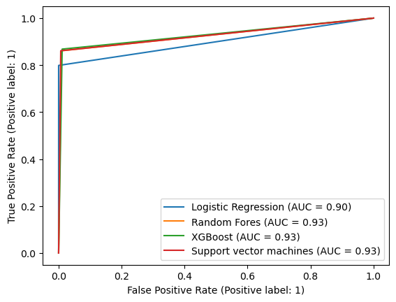

```python
fig, ax = plt.subplots()
RocCurveDisplay.from_predictions(y_test_3, pred_y_LR_3, ax=ax, name = 'Logistic Regression')
RocCurveDisplay.from_predictions(y_test_3, pred_y_RF_3, ax=ax, name = 'Random Fores')
RocCurveDisplay.from_predictions(y_test_3, pred_y_XGB_3, ax=ax, name = 'XGBoost')
RocCurveDisplay.from_predictions(y_test_3, pred_y_SVC_3, ax=ax, name = 'Support vector machines')
plt.show()
```

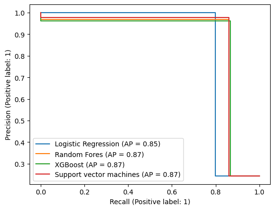

```python
fig, ax = plt.subplots()
PrecisionRecallDisplay.from_predictions(y_test_3, pred_y_LR_3, ax=ax, name = 'Logistic Regression')
PrecisionRecallDisplay.from_predictions(y_test_3, pred_y_RF_3, ax=ax, name = 'Random Fores')
PrecisionRecallDisplay.from_predictions(y_test_3, pred_y_XGB_3, ax=ax, name = 'XGBoost')
PrecisionRecallDisplay.from_predictions(y_test_3, pred_y_SVC_3, ax=ax, name = 'Support vector machines')
plt.show()
```

```python
pred_dict = {'Logistic Regression':pred_y_LR_3,
               'Random Forest Classifier':pred_y_RF_3,
               'Gradient Boosting Classifier':pred_y_XGB_3,
               'Support vector machines':pred_y_SVC_3}

for name, pred in pred_dict.items():
    print(f"Confusion Matrix of {name} for Sparse Autoencoder:")
    print(confusion_matrix(y_test_3, pred))
    print ("")
    print (f"Classification Report of {name} for Sparse Autoencoder: ")
    print (classification_report(y_test_3, pred))
```

```
Confusion Matrix of Logistic Regression for Sparse Autoencoder:
[[447   0]
 [ 29 115]]

Classification Report of Logistic Regression for Sparse Autoencoder:
              precision    recall  f1-score   support

           0       0.94      1.00      0.97       447
           1       1.00      0.80      0.89       144

    accuracy                           0.95       591
   macro avg       0.97      0.90      0.93       591
weighted avg       0.95      0.95      0.95       591

Confusion Matrix of Random Forest Classifier for Sparse Autoencoder:
[[443   4]
 [ 20 124]]

Classification Report of Random Forest Classifier for Sparse Autoencoder:
              precision    recall  f1-score   support

           0       0.96      0.99      0.97       447
           1       0.97      0.86      0.91       144

    accuracy                           0.96       591
   macro avg       0.96      0.93      0.94       591
weighted avg       0.96      0.96      0.96       591

Confusion Matrix of Gradient Boosting Classifier for Sparse Autoencoder:
[[442   5]
 [ 19 125]]

Classification Report of Gradient Boosting Classifier for Sparse Autoencoder:
              precision    recall  f1-score   support

           0       0.96      0.99      0.97       447
           1       0.96      0.87      0.91       144

    accuracy                           0.96       591
   macro avg       0.96      0.93      0.94       591
weighted avg       0.96      0.96      0.96       591

Confusion Matrix of Support vector machines for Sparse Autoencoder:
[[444   3]
 [ 20 124]]

Classification Report of Support vector machines for Sparse Autoencoder:
              precision    recall  f1-score   support

           0       0.96      0.99      0.97       447
           1       0.98      0.86      0.92       144

    accuracy                           0.96       591
   macro avg       0.97      0.93      0.94       591
weighted avg       0.96      0.96      0.96       591
```